# TALLER: UNA GUÍA PRÁCTICA PARA USAR LOS DATOS DEL BARÓMETRO DE LAS AMÉRICAS

Arturo Maldonado - Pontificia Universidad Católica del Perú

22/09/2020

# REPLICACIÓN DEL INSIGHTS 142

# ¿QUIÉNES CONFÍAN EN LOS MEDIOS DE COMUNICACIÓN EN LAS AMÉRICAS?

# Autora: Hannah Hagan - Vanderbilt University

## ABSTRACT

En este taller vamos a replicar el informe 142 de la Serie Perspectivas desde el Barómetro de las Américas. Se puede ver aquí la lista de los reportes [aquí](https://www.vanderbilt.edu/lapop-espanol/perspectivas/). El informe 142 se puede conseguir en español [aquí](https://www.vanderbilt.edu/lapop/insights/IO942es.pdf). Para este taller, se asume que los participantes tienen un conocimiento básico de R y RStudio. A lo largo de este taller, explicaremos, paso a paso, los procedimientos en RStudio para producir las tablas y gráficos que se ven en los informes. En estos informes, estas tablas y gráficos han sido producidos originalmente en STATA.

En resumen, este informe presenta el promedio de confianza en los medios de comunicación en las Américas y dos modelos explicativos de la confianza en los medios usando factores socioeconómicos y factores políticos en modelos de regresión lineal.

## SOBRE LA BASE DE DATOS

Los datos que vamos a usar deben citarse de la siguiente manera: Fuente: Barómetro de las Américas por el Proyecto de Opinión Pública de América Latina (LAPOP), wwww.LapopSurveys.org.

Pueden descargar los datos de manera libre [aquí](http://datasets.americasbarometer.org/database/login.php)

En este enlace, se puede registrar o entrar como “Free User”. En el buscador, se puede ingresar el texto “merge”. Ahí se tendrá acceso a la base de datos completa “2004-2018 Grand Merge Free” en versión para STATA. Se descarga la base de datos en formato zip, la que se descomprime en formato .dta.

Debido a que estas bases de datos son muy grandes (42MB en formato zip), para este taller vamos a trabajar con una versión reducida, que incluye los países y años seleccionados en el informe. Esta base de datos y todos los materiales para esta taller se pueden descargar [aquí](https://github.com/arturomaldonado/TallerLAPOP2020.git)

## INSTALANDO LOS PAQUETES NECESARIOS EN R

```r
library(rio) # Para importar los datos
library(ggplot2) # Para hacer gráficos tipo ggplot
library(Rmisc) # Para poder usar la función summarySE
library(descr) # Para poder usar la función crosstab y compmeans
```

## LEYENDO LA BASE DE DATOS EN R

###Si se trabajara con la base de datos descargada del repositorio de LAPOP

Se carga la base de datos de STATA en R en un dataframe “lapopmerge”. Tenga en cuenta que la base de datos tiene que estar en su directorio de trabajo (working directory). Para este Insights se analiza la ronda 2016/17, por lo que se selecciona esta ronda en el merge total. Se crea un nuevo dataframe “lapop”. Luego, también se elimina las observaciones de los países que no se analizan en este reporte por no tener datos de la variable sobre medios de comunicación. Se elimina el dataframe del Merge original. Finalmente el dataframe “lapop” incluye solo la ronda 2016/17 y los países de análisis.

```r
lapopmerge <- import("LAPOP_Merge_2004_2018.dta")
lapop <- subset(lapopmerge, wave==2016)
lapop <- subset(lapop, pais<=23 | pais>=40)
rm(lapopmerge)
```

En este taller vamos a trabajar con una versión simplificada de la base de datos, que incluye solo las variables necesarias para el análisis. Esta base reducida directamente la leemos en RStudio y seleccionamos la ronda de trabajo.

```r
lapop <- import("LAPOP_reduced_merge.dta")
lapop <- subset(lapop, wave==2016)
```

La autora indica que para este reporte se ha usado la pregunta: B37: ¿Hasta qué punto tiene usted confianza en los medios de comunicación?

## GRÁFICO 1

La escala original de la variable iba de 1 a 7, donde 1 indica “Nada” y 7 “Mucho”. Para reproducir la Figura 1 primero se tiene que recodificar la variable dependiente b37 en una nueva variable b37r. El texto indica que la recodificación es como sigue: valores entre 1 y 4 tienen un nuevo valor de 0 y valores entre 5 y 7, un nuevo valor de 100.

```r
library(car) # Para poder usar el comando recode
lapop$b37r <- recode(lapop$b37, "1:4=0 ; 5:7=100")
table(lapop$b37r)
```

```
##
##     0   100
## 17487 17568
```

Al momento de leer la base de datos en R, este programa importa las variables como numéricas. La variable “pais” se tiene que convertir en una variable de tipo “factor” y se tiene que etiquetar.

```r
lapop$pais = as.factor(lapop$pais)
levels(lapop$pais) <- c("México", "Guatemala", "El Salvador", "Honduras",
                            "Nicaragua","Costa Rica", "Panamá", "Colombia",
                            "Ecuador", "Bolivia", "Perú", "Paraguay",
                            "Chile", "Uruguay", "Brasil", "Venezuela",
                            "Argentina", "Rep. Dom.", "Haití", "Jamaica",
                            "Estados Unidos", "Canada")
levels(lapop$pais)
```

```
##  [1] "México"         "Guatemala"      "El Salvador"    "Honduras"
##  [5] "Nicaragua"      "Costa Rica"     "Panamá"         "Colombia"
##  [9] "Ecuador"        "Bolivia"        "Perú"           "Paraguay"
## [13] "Chile"          "Uruguay"        "Brasil"         "Venezuela"
## [17] "Argentina"      "Rep. Dom."      "Haití"          "Jamaica"
## [21] "Estados Unidos" "Canada"
```

```r
table(lapop$pais)
```

```
##
##         México      Guatemala    El Salvador       Honduras      Nicaragua
##           1563           1546           1551           1560           1560
##     Costa Rica         Panamá       Colombia        Ecuador        Bolivia
##           1514           1521           1563           1545           1691
##           Perú       Paraguay          Chile        Uruguay         Brasil
##           2647           1528           1625           1514           1532
##      Venezuela      Argentina      Rep. Dom.          Haití        Jamaica
##           1558           1528           1518           2221           1515
## Estados Unidos         Canada
##           1500           1511
```

```r
table(lapop$pais, lapop$year)
```

```
##
##                  2016 2017
##   México         1563    0
##   Guatemala         0 1546
##   El Salvador    1551    0
##   Honduras       1560    0
##   Nicaragua      1560    0
##   Costa Rica     1514    0
##   Panamá            0 1521
##   Colombia       1563    0
##   Ecuador        1545    0
##   Bolivia           0 1691
##   Perú              0 2647
##   Paraguay       1528    0
##   Chile             0 1625
##   Uruguay           0 1514
##   Brasil            0 1532
##   Venezuela      1558    0
##   Argentina         0 1528
##   Rep. Dom.      1518    0
##   Haití             0 2221
##   Jamaica           0 1515
##   Estados Unidos    0 1500
##   Canada            0 1511
```

Estos datos, sin embargo, no toman en cuenta el efecto del diseño muestral. En este análisis se asume que todos los países tienen el mismo peso, a pesar que cada país tenga un tamaño de muestra diferente. LAPOP incluye en sus bases de datos una variable que es un factor de ponderación (“weight1500”), que fija un tamaño de muestra de 1,500 casos como peso de cada país. Para tomar en cuenta esta ponderación se puede usar, por ejemplo, el siguiente código para ver el tamaño de muestra ponderada por país:

```r
crosstab(lapop$pais, lapop$year, weight=lapop$weight1500, plot=F)
```

```
##    Cell Contents
## |-------------------------|
## |                   Count |
## |-------------------------|
##
## =======================================
##                   lapop$year
## lapop$pais         2016    2017   Total
## ---------------------------------------
## México             1500       0    1500
## ---------------------------------------
## Guatemala             0    1500    1500
## ---------------------------------------
## El Salvador        1500       0    1500
## ---------------------------------------
## Honduras           1500       0    1500
## ---------------------------------------
## Nicaragua          1500       0    1500
## ---------------------------------------
## Costa Rica         1500       0    1500
## ---------------------------------------
## Panamá                0    1500    1500
## ---------------------------------------
## Colombia           1500       0    1500
## ---------------------------------------
## Ecuador            1500       0    1500
## ---------------------------------------
## Bolivia               0    1500    1500
## ---------------------------------------
## Perú                  0    1500    1500
## ---------------------------------------
## Paraguay           1500       0    1500
## ---------------------------------------
## Chile                 0    1500    1500
## ---------------------------------------
## Uruguay               0    1500    1500
## ---------------------------------------
## Brasil                0    1500    1500
## ---------------------------------------
## Venezuela          1500       0    1500
## ---------------------------------------
## Argentina             0    1500    1500
## ---------------------------------------
## Rep. Dom.          1500       0    1500
## ---------------------------------------
## Haití                 0    1500    1500
## ---------------------------------------
## Jamaica               0    1500    1500
## ---------------------------------------
## Estados Unidos        0    1500    1500
## ---------------------------------------
## Canada                0    1500    1500
## ---------------------------------------
## Total             1.5e+04   1.8e+04   3.3e+04
## =======================================
```

*Sin tomar en cuenta el efecto de diseño*

Para reproducir el gráfico 1 sin tomar en cuenta el efecto de diseño, se calculan los datos de % e intervalos de confianza de la variable b37r por cada país y se guarda en un objeto “df”

```r
df <- summarySE(data=lapop, measurevar="b37r", groupvar="pais", na.rm=T)
```

Con estos datos, se construye el gráfico 1 con el siguiente código. Tenemos que tomar en cuenta que en algunos países los % no son similares porque este código no incluye las ponderaciones muestrales.

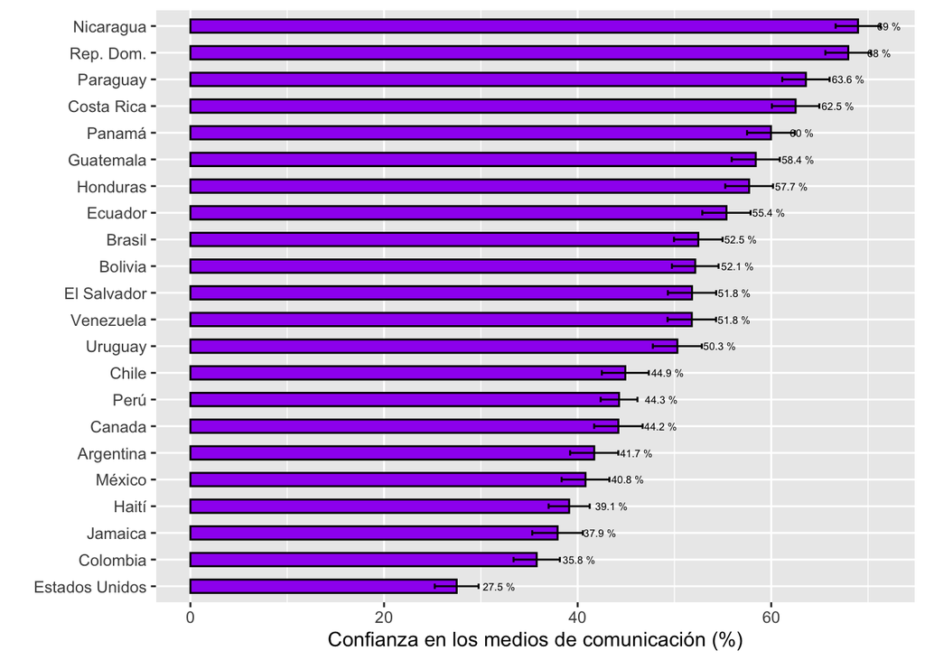

```r
graf1 <- ggplot(df, aes(x=reorder(pais, b37r), y=b37r)) +
  geom_bar(width=0.5, fill="purple", colour="black", stat="identity") +
  geom_errorbar(aes(ymin=b37r-ci, ymax=b37r+ci), width= 0.2) +
  geom_text(aes(label=paste(round(b37r, 1), "%")), hjust=-0.8, size=2) +
  xlab("") +
  ylab("Confianza en los medios de comunicación (%)")  +
  coord_flip()
graf1
```

*Para tomar en cuenta el efecto de diseño*

Para reproducir el gráfico 1, tomando en cuenta el diseño muestral se tiene que seguir el siguiente código para la creación de un objeto con los datos ponderados. Este código permite incluir la variable “weight1500”.

```r
tab.b37r <- as.data.frame(compmeans(lapop$b37r, lapop$pais, lapop$weight1500, plot=FALSE))
tab.b37r
```

```
##                    Mean     N Std. Dev.
## México         40.81365  1463  49.16568
## Guatemala      58.39947  1467  49.30625
## El Salvador    51.81582  1491  49.98378
## Honduras       57.71725  1483  49.41752
## Nicaragua      68.96552  1478  46.27914
## Costa Rica     62.51664  1488  48.42426
## Panamá         59.97349  1488  49.01167
## Colombia       35.76973  1484  47.94840
## Ecuador        55.37353  1482  49.72720
## Bolivia        52.14761  1466  49.97090
## Perú           41.00866  1493  49.20139
## Paraguay       63.58149  1464  48.13654
## Chile          44.92574  1492  49.75853
## Uruguay        50.30020  1485  50.01594
## Brasil         51.13239  1491  50.00394
## Venezuela      51.79387  1476  49.98475
## Argentina      41.71088  1480  49.32478
## Rep. Dom.      67.95470  1483  46.68081
## Haití          39.48932  1370  48.90062
## Jamaica        37.92581  1308  48.53880
## Estados Unidos 29.76783  1496  45.73902
## Canada         43.72953  1500  49.62180
## Total          50.39250 32328  49.99923
```

Luego, este dataframe se tiene que adecuar para poder producir el gráfico. Se cambia el nombre de las columnas y se agregan los datos de “pais”, “error estándar” e “intervalo de confianza”. También se elimina la fila 23 “Total” que produce el código anterior.

```r
varnames <- c("media", "n", "sd")
colnames(tab.b37r) <- varnames
tab.b37r$pais <- row.names(tab.b37r)
tab.b37r$err.st <- tab.b37r$sd/sqrt(tab.b37r$n)
tab.b37r$ci <- tab.b37r$err.st*1.96
tab.b37r <- tab.b37r[-23, ]
tab.b37r
```

```
##                   media    n       sd           pais   err.st       ci
## México         40.81365 1463 49.16568         México 1.285405 2.519393
## Guatemala      58.39947 1467 49.30625      Guatemala 1.287321 2.523149
## El Salvador    51.81582 1491 49.98378    El Salvador 1.294465 2.537151
## Honduras       57.71725 1483 49.41752       Honduras 1.283247 2.515165
## Nicaragua      68.96552 1478 46.27914      Nicaragua 1.203782 2.359414
## Costa Rica     62.51664 1488 48.42426     Costa Rica 1.255341 2.460468
## Panamá         59.97349 1488 49.01167         Panamá 1.270568 2.490314
## Colombia       35.76973 1484 47.94840       Colombia 1.244678 2.439570
## Ecuador        55.37353 1482 49.72720        Ecuador 1.291724 2.531780
## Bolivia        52.14761 1466 49.97090        Bolivia 1.305119 2.558034
## Perú           41.00866 1493 49.20139           Perú 1.273349 2.495764
## Paraguay       63.58149 1464 48.13654       Paraguay 1.258069 2.465814
## Chile          44.92574 1492 49.75853          Chile 1.288200 2.524871
## Uruguay        50.30020 1485 50.01594        Uruguay 1.297912 2.543907
## Brasil         51.13239 1491 50.00394         Brasil 1.294987 2.538175
## Venezuela      51.79387 1476 49.98475      Venezuela 1.301051 2.550060
## Argentina      41.71088 1480 49.32478      Argentina 1.282137 2.512988
## Rep. Dom.      67.95470 1483 46.68081      Rep. Dom. 1.212182 2.375877
## Haití          39.48932 1370 48.90062          Haití 1.321156 2.589466
## Jamaica        37.92581 1308 48.53880        Jamaica 1.342101 2.630518
## Estados Unidos 29.76783 1496 45.73902 Estados Unidos 1.182554 2.317806
## Canada         43.72953 1500 49.62180         Canada 1.281229 2.511209
```

Con este dataframe se puede producir el gráfico con los datos ponderados.

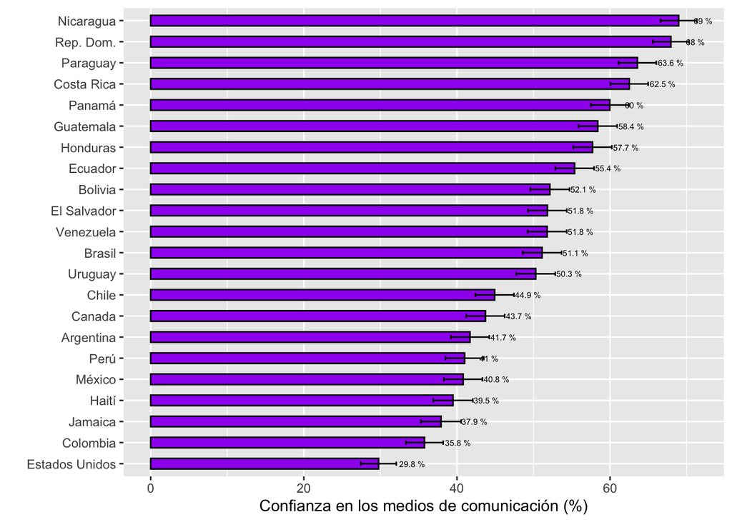

```r
graf142_1 <- ggplot(tab.b37r, aes(x=reorder(pais, media), y=media)) +
  geom_bar(width=0.5, fill="purple", colour="black", stat="identity")+
  geom_errorbar(aes(ymin=media-ci, ymax=media+ci), width=0.2)+
  geom_text(aes(label=paste(round(media, 1), "%")), hjust=-0.8, size=2)+
  xlab("") + ylab("Confianza en los medios de comunicación (%)")+
  coord_flip()
graf142_1
```

# FACTORES SOCIODEMOGRÁFICOS Y CONFIANZA EN LOS MEDIOS DE COMUNICACIÓN

La autora indica que para el gráfico 2 va a usar un modelo de regresión de mínimos cuadrados ordinarios (OLS), usando seis características demográficas y socioeconómicas como predictores de la confianza reportada en los medios de comunicación

## GRÁFICO 2

Para repreducir el segundo gráfico se tiene que recodificar las variables independientes para que varíen entre 0 y 1.

```r
lapop$edrr <- lapop$edr/3
lapop$size <- (5-lapop$tamano)/4
lapop$edadr <- (lapop$edad -1)/5
lapop$tono <- (lapop$colorr-1)/10
lapop$nse <- (lapop$quintall-1)/4
```

Luego de recodificar las variables, se tiene que correr el modelo usando como variable dependiente b37 y las variables recodificadas como variables independientes. Para la creación de este gráfico, también se tiene que tomar en cuenta la ponderación. Para esto usamos la libreria “survey” y guardamos las características del diseño en un objeto “lapop.design”.

```r
library(survey) # Para poder definir las características del diseño muestral
lapop.design<-svydesign(ids =~upm, strata =~ estratopri, weights = ~weight1500, nest=TRUE, data=lapop)
```

El modelo de regresión incluye variables dummy por país, aunque no se mostrarán en el gráfico. Para calcular los coeficientes tomando en cuenta el diseño muestral, se usa el comando “svyglm”. Se guardan los resultados en un objeto “modelo142_1”.

```r
modelo142_1 <- svyglm(b37 ~ mujer + edrr + size +
                        edadr + tono + nse + factor(pais), design=lapop.design)
modelo142_1
```

```
## Stratified 1 - level Cluster Sampling design (with replacement)
## With (1640) clusters.
## svydesign(ids = ~upm, strata = ~estratopri, weights = ~weight1500,
##     nest = TRUE, data = lapop)
##
## Call:  svyglm(formula = b37 ~ mujer + edrr + size + edadr + tono + nse +
##     factor(pais), design = lapop.design)
##
## Coefficients:
##             (Intercept)                    mujer                     edrr
##                 4.51300                  0.15314                 -0.72534
##                    size                    edadr                     tono
##                -0.25415                  0.04773                  0.16804
##                     nse    factor(pais)Guatemala  factor(pais)El Salvador
##                -0.22429                  0.65679                  0.42794
##    factor(pais)Honduras    factor(pais)Nicaragua   factor(pais)Costa Rica
##                 0.59724                  1.11074                  0.84112
##      factor(pais)Panamá     factor(pais)Colombia      factor(pais)Ecuador
##                 0.79051                 -0.14519                  0.76325
##     factor(pais)Bolivia         factor(pais)Perú     factor(pais)Paraguay
##                 0.60803                  0.23859                  0.87424
##       factor(pais)Chile      factor(pais)Uruguay       factor(pais)Brasil
##                 0.29237                  0.49288                  0.47083
##   factor(pais)Venezuela    factor(pais)Argentina    factor(pais)Rep. Dom.
##                 0.60390                  0.08247                  1.08458
##       factor(pais)Haití      factor(pais)Jamaica
##                -0.25088                 -0.06650
##
## Degrees of Freedom: 30917 Total (i.e. Null);  1506 Residual
##   (4893 observations deleted due to missingness)
## Null Deviance:       104200
## Residual Deviance: 96890     AIC: 124600
```

Para visualizar mejor los resultados, podemos usar el siguiente código:

```r
library(jtools) # Para poder usar el comando siguiente
export_summs(modelo142_1)
```

|  | Model 1 |
| --- | --- |
| (Intercept) | 4.51 *** |
|  | (0.08) |
| mujer | 0.15 *** |
|  | (0.02) |
| edrr | -0.73 *** |
|  | (0.05) |
| size | -0.25 *** |
|  | (0.03) |
| edadr | 0.05 |
|  | (0.04) |
| tono | 0.17 * |
|  | (0.07) |
| nse | -0.22 *** |
|  | (0.03) |
| factor(pais)Guatemala | 0.66 *** |
|  | (0.08) |
| factor(pais)El Salvador | 0.43 *** |
|  | (0.07) |
| factor(pais)Honduras | 0.60 *** |
|  | (0.08) |
| factor(pais)Nicaragua | 1.11 *** |
|  | (0.07) |
| factor(pais)Costa Rica | 0.84 *** |
|  | (0.08) |
| factor(pais)Panamá | 0.79 *** |
|  | (0.08) |
| factor(pais)Colombia | -0.15 |
|  | (0.08) |
| factor(pais)Ecuador | 0.76 *** |
|  | (0.08) |
| factor(pais)Bolivia | 0.61 *** |
|  | (0.07) |
| factor(pais)Perú | 0.24 ** |
|  | (0.07) |
| factor(pais)Paraguay | 0.87 *** |
|  | (0.07) |
| factor(pais)Chile | 0.29 *** |
|  | (0.08) |
| factor(pais)Uruguay | 0.49 *** |
|  | (0.08) |
| factor(pais)Brasil | 0.47 *** |
|  | (0.08) |
| factor(pais)Venezuela | 0.60 *** |
|  | (0.08) |
| factor(pais)Argentina | 0.08 |
|  | (0.08) |
| factor(pais)Rep. Dom. | 1.08 *** |
|  | (0.08) |
| factor(pais)Haití | -0.25 ** |
|  | (0.08) |
| factor(pais)Jamaica | -0.07 |
|  | (0.08) |
| N | 30918 |
| R2 | 0.07 |
| *** p < 0.001; ** p < 0.01; * p < 0.05. |  |

Para reproducir el gráfico 2, podemos usar el siguiente código:

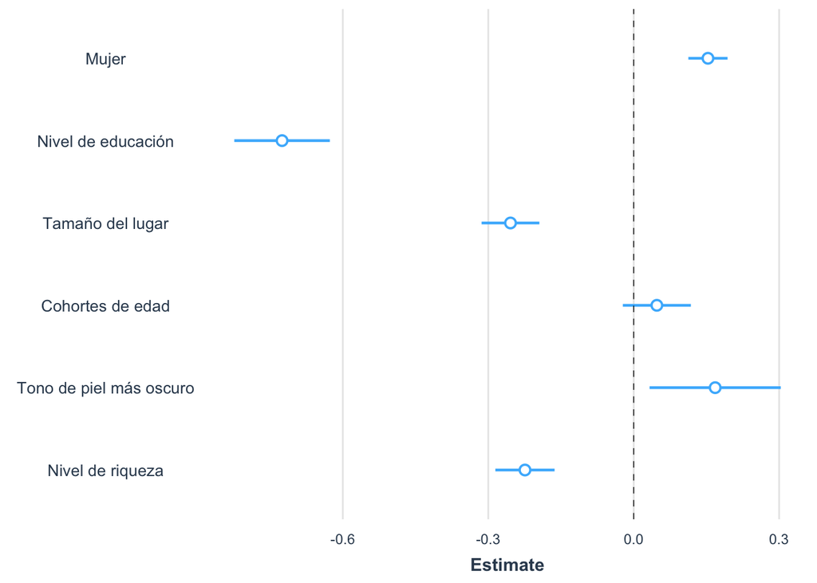

```r
plot_summs(modelo142_1, coefs=c("Mujer" = "mujer",
                                 "Nivel de educación" = "edrr",
                                 "Tamaño del lugar" = "size",
                                 "Cohortes de edad" = "edadr",
                                 "Tono de piel más oscuro" = "tono",
                                 "Nivel de riqueza" = "nse"))
```

# EXPLICACIONES ADICIONALES DE LA CONFIANZA EN LOS MEDIOS DE COMUNICACIÓN

Como indica la autora: “El Gráfico 3 incorpora al modelo la confianza interpersonal, asistencia a los servicios religiosos, la atención que le prestan a las noticias, uso de internet, interés en política, identificación con un partido político, satisfacción con la democracia, y el voto en las elecciones presidenciales más recientes. De forma similar al Gráfico 2, los efectos estimados que aparecen en el Gráfico 3 son calculados con un modelo de regresión de mínimos cuadrados”.

## GRÁFICO 3

Para reproducir el gráfico 3, primero se tienen que recodificar las variables independientes.

```r
lapop$it1r <- (4 - lapop$it1) / 3
lapop$q5a01 <- recode(lapop$q5a, "1:4=1; 5=0")
lapop$satisdem <- (4 - lapop$pn4) / 3
lapop$useinternet <- (5 - lapop$www1) / 4
lapop$newsattn <- (5 - lapop$gi0) / 4
lapop$polinterest <- (4 - lapop$pol1) / 3
lapop$idpty <- recode(lapop$vb10, "1=1; 2=0")
lapop$voted <- recode(lapop$vb2, "1=1; 2=0")
```

Se crea una variable “votewinner” que recodifica a aquellos que votaron al candidato ganador de la última elección presidencial en cada país. Esta variable se reconstruye recodificando la variable vb3n_16, que recoge el voto reportado por cada entrevistado en cada país.

```r
lapop$votewinner <- NA
lapop <- within(lapop, {
                votewinner[vb2==2] <- 0
                votewinner[vb3n_16==0] <- 0
                votewinner[vb3n_16==97] <- 0
                votewinner[vb3n_16==102] <- 0
                votewinner[vb3n_16==103] <- 0
                votewinner[vb3n_16==104] <- 0
                votewinner[vb3n_16==177] <- 0
                votewinner[vb3n_16==202] <- 0
                votewinner[vb3n_16==203] <- 0
                votewinner[vb3n_16==204] <- 0
                votewinner[vb3n_16==205] <- 0
                votewinner[vb3n_16==206] <- 0
                votewinner[vb3n_16==207] <- 0
                votewinner[vb3n_16==208] <- 0
                votewinner[vb3n_16==209] <- 0
                votewinner[vb3n_16==210] <- 0
                votewinner[vb3n_16==211] <- 0
                votewinner[vb3n_16==212] <- 0
                votewinner[vb3n_16==213] <- 0
                votewinner[vb3n_16==214] <- 0
                votewinner[vb3n_16==277] <- 0
                votewinner[vb3n_16==301] <- 0
                votewinner[vb3n_16==303] <- 0
                votewinner[vb3n_16==377] <- 0
                votewinner[vb3n_16==402] <- 0
                votewinner[vb3n_16==403] <- 0
                votewinner[vb3n_16==404] <- 0
                votewinner[vb3n_16==407] <- 0
                votewinner[vb3n_16==408] <- 0
                votewinner[vb3n_16==477] <- 0
                votewinner[vb3n_16==501] <- 0
                votewinner[vb3n_16==503] <- 0
                votewinner[vb3n_16==504] <- 0
                votewinner[vb3n_16==505] <- 0
                votewinner[vb3n_16==577] <- 0
                votewinner[vb3n_16==601] <- 0
                votewinner[vb3n_16==602] <- 0
                votewinner[vb3n_16==604] <- 0
                votewinner[vb3n_16==605] <- 0
                votewinner[vb3n_16==677] <- 0
                votewinner[vb3n_16==702] <- 0
                votewinner[vb3n_16==703] <- 0
                votewinner[vb3n_16==777] <- 0
                votewinner[vb3n_16==801] <- 0
                votewinner[vb3n_16==802] <- 0
                votewinner[vb3n_16==803] <- 0
                votewinner[vb3n_16==805] <- 0
                votewinner[vb3n_16==877] <- 0
                votewinner[vb3n_16==902] <- 0
                votewinner[vb3n_16==903] <- 0
                votewinner[vb3n_16==904] <- 0
                votewinner[vb3n_16==905] <- 0
                votewinner[vb3n_16==906] <- 0
                votewinner[vb3n_16==908] <- 0
                votewinner[vb3n_16==977] <- 0
                votewinner[vb3n_16==1002] <- 0
                votewinner[vb3n_16==1003] <- 0
                votewinner[vb3n_16==1004] <- 0
                votewinner[vb3n_16==1005] <- 0
                votewinner[vb3n_16==1077] <- 0
                votewinner[vb3n_16==1102] <- 0
                votewinner[vb3n_16==1103] <- 0
                votewinner[vb3n_16==1104] <- 0
                votewinner[vb3n_16==1105] <- 0
                votewinner[vb3n_16==1106] <- 0
                votewinner[vb3n_16==1107] <- 0
                votewinner[vb3n_16==1108] <- 0
                votewinner[vb3n_16==1177] <- 0
                votewinner[vb3n_16==1202] <- 0
                votewinner[vb3n_16==1203] <- 0
                votewinner[vb3n_16==1204] <- 0
                votewinner[vb3n_16==1205] <- 0
                votewinner[vb3n_16==1206] <- 0
                votewinner[vb3n_16==1277] <- 0
                votewinner[vb3n_16==1303] <- 0
                votewinner[vb3n_16==1306] <- 0
                votewinner[vb3n_16==1307] <- 0
                votewinner[vb3n_16==1309] <- 0
                votewinner[vb3n_16==1310] <- 0
                votewinner[vb3n_16==1311] <- 0
                votewinner[vb3n_16==1377] <- 0
                votewinner[vb3n_16==1402] <- 0
                votewinner[vb3n_16==1403] <- 0
                votewinner[vb3n_16==1404] <- 0
                votewinner[vb3n_16==1405] <- 0
                votewinner[vb3n_16==1406] <- 0
                votewinner[vb3n_16==1477] <- 0
                votewinner[vb3n_16==1502] <- 0
                votewinner[vb3n_16==1503] <- 0
                votewinner[vb3n_16==1577] <- 0
                votewinner[vb3n_16==1602] <- 0
                votewinner[vb3n_16==1604] <- 0
                votewinner[vb3n_16==1605] <- 0
                votewinner[vb3n_16==1677] <- 0
                votewinner[vb3n_16==1702] <- 0
                votewinner[vb3n_16==1703] <- 0
                votewinner[vb3n_16==1704] <- 0
                votewinner[vb3n_16==1705] <- 0
                votewinner[vb3n_16==1777] <- 0
                votewinner[vb3n_16==2102] <- 0
                votewinner[vb3n_16==2103] <- 0
                votewinner[vb3n_16==2177] <- 0
                votewinner[vb3n_16==2202] <- 0
                votewinner[vb3n_16==2203] <- 0
                votewinner[vb3n_16==2204] <- 0
                votewinner[vb3n_16==2205] <- 0
                votewinner[vb3n_16==2206] <- 0
                votewinner[vb3n_16==2277] <- 0
                votewinner[vb3n_16==2301] <- 0
                votewinner[vb3n_16==2377] <- 0
                votewinner[vb3n_16==2402] <- 0
                votewinner[vb3n_16==2477] <- 0
                votewinner[vb3n_16==4001] <- 0
                votewinner[vb3n_16==4003] <- 0
                votewinner[vb3n_16==4004] <- 0
                votewinner[vb3n_16==4077] <- 0
                votewinner[vb3n_16==1701] <- 1
                votewinner[vb3n_16==1001] <- 1
                votewinner[vb3n_16==1501] <- 1
                votewinner[vb3n_16==1305] <- 1
                votewinner[vb3n_16==804] <- 1
                votewinner[vb3n_16==603] <- 1
                votewinner[vb3n_16==2101] <- 1
                votewinner[vb3n_16==901] <- 1
                votewinner[vb3n_16==302] <- 1
                votewinner[vb3n_16==201] <- 1
                votewinner[vb3n_16==2401] <- 1
                votewinner[vb3n_16==2201] <- 1
                votewinner[vb3n_16==401] <- 1
                votewinner[vb3n_16==2302] <- 1
                votewinner[vb3n_16==101] <- 1
                votewinner[vb3n_16==502] <- 1
                votewinner[vb3n_16==701] <- 1
                votewinner[vb3n_16==1201] <- 1
                votewinner[vb3n_16==1101] <- 1
                votewinner[vb3n_16==4002] <- 1
                votewinner[vb3n_16==1401] <- 1
                votewinner[vb3n_16==1601] <- 1
})
table(lapop$votewinner)
```

```
##
##     0     1
## 17836 11024
```

Se tiene que volver a calcular el efecto de diseño muestral para que incluya a estas variables recodificadas.

```r
lapop.design<-svydesign(ids =~upm, strata =~ estratopri, weights = ~weight1500, nest=TRUE, data=lapop)
```

Luego de la recodificación, se corre el modelo y se guardan los resultados en el objeto “modelo42_2”.

```r
modelo142_2 <- svyglm(b37 ~ it1r + q5a01 + newsattn + useinternet +
                         polinterest + idpty + satisdem + votewinner +
                         tono + edrr + edadr + size + nse + mujer +
                         factor(pais), design=lapop.design)
modelo142_2
```

```
## Stratified 1 - level Cluster Sampling design (with replacement)
## With (1640) clusters.
## svydesign(ids = ~upm, strata = ~estratopri, weights = ~weight1500,
##     nest = TRUE, data = lapop)
##
## Call:  svyglm(formula = b37 ~ it1r + q5a01 + newsattn + useinternet +
##     polinterest + idpty + satisdem + votewinner + tono + edrr +
##     edadr + size + nse + mujer + factor(pais), design = lapop.design)
##
## Coefficients:
##             (Intercept)                     it1r                    q5a01
##                 3.62974                  0.30689                  0.21534
##                newsattn              useinternet              polinterest
##                 0.67399                 -0.27496                  0.01232
##                   idpty                 satisdem               votewinner
##                 0.05061                  0.75676                  0.06423
##                    tono                     edrr                    edadr
##                 0.10872                 -0.70411                 -0.29220
##                    size                      nse                    mujer
##                -0.18041                 -0.23195                  0.16502
##   factor(pais)Guatemala  factor(pais)El Salvador     factor(pais)Honduras
##                 0.54078                  0.23532                  0.43613
##   factor(pais)Nicaragua   factor(pais)Costa Rica       factor(pais)Panamá
##                 0.85157                  0.69868                  0.69259
##    factor(pais)Colombia      factor(pais)Ecuador      factor(pais)Bolivia
##                -0.23244                  0.55200                  0.44029
##        factor(pais)Perú     factor(pais)Paraguay        factor(pais)Chile
##                 0.16533                  0.73078                  0.25738
##     factor(pais)Uruguay       factor(pais)Brasil    factor(pais)Venezuela
##                 0.28872                  0.48553                  0.59085
##   factor(pais)Argentina    factor(pais)Rep. Dom.        factor(pais)Haití
##                 0.01594                  0.95094                 -0.08342
##     factor(pais)Jamaica
##                -0.15465
##
## Degrees of Freedom: 24166 Total (i.e. Null);  1498 Residual
##   (11644 observations deleted due to missingness)
## Null Deviance:       81070
## Residual Deviance: 72610     AIC: 96540
```

Para visualizar mejor los resultados, podemos usar el siguiente código. Incluso se puede comparar ambos modelos:

```r
export_summs(modelo142_1, modelo142_2)
```

|  | Model 1 | Model 2 |
| --- | --- | --- |
| (Intercept) | 4.51 *** | 3.63 *** |
|  | (0.08) | (0.09) |
| mujer | 0.15 *** | 0.17 *** |
|  | (0.02) | (0.02) |
| edrr | -0.73 *** | -0.70 *** |
|  | (0.05) | (0.06) |
| size | -0.25 *** | -0.18 *** |
|  | (0.03) | (0.03) |
| edadr | 0.05 | -0.29 *** |
|  | (0.04) | (0.05) |
| tono | 0.17 * | 0.11 |
|  | (0.07) | (0.08) |
| nse | -0.22 *** | -0.23 *** |
|  | (0.03) | (0.04) |
| factor(pais)Guatemala | 0.66 *** | 0.54 *** |
|  | (0.08) | (0.08) |
| factor(pais)El Salvador | 0.43 *** | 0.24 ** |
|  | (0.07) | (0.08) |
| factor(pais)Honduras | 0.60 *** | 0.44 *** |
|  | (0.08) | (0.09) |
| factor(pais)Nicaragua | 1.11 *** | 0.85 *** |
|  | (0.07) | (0.08) |
| factor(pais)Costa Rica | 0.84 *** | 0.70 *** |
|  | (0.08) | (0.09) |
| factor(pais)Panamá | 0.79 *** | 0.69 *** |
|  | (0.08) | (0.08) |
| factor(pais)Colombia | -0.15 | -0.23 ** |
|  | (0.08) | (0.08) |
| factor(pais)Ecuador | 0.76 *** | 0.55 *** |
|  | (0.08) | (0.09) |
| factor(pais)Bolivia | 0.61 *** | 0.44 *** |
|  | (0.07) | (0.08) |
| factor(pais)Perú | 0.24 ** | 0.17 * |
|  | (0.07) | (0.08) |
| factor(pais)Paraguay | 0.87 *** | 0.73 *** |
|  | (0.07) | (0.08) |
| factor(pais)Chile | 0.29 *** | 0.26 ** |
|  | (0.08) | (0.09) |
| factor(pais)Uruguay | 0.49 *** | 0.29 *** |
|  | (0.08) | (0.09) |
| factor(pais)Brasil | 0.47 *** | 0.49 *** |
|  | (0.08) | (0.09) |
| factor(pais)Venezuela | 0.60 *** | 0.59 *** |
|  | (0.08) | (0.09) |
| factor(pais)Argentina | 0.08 | 0.02 |
|  | (0.08) | (0.09) |
| factor(pais)Rep. Dom. | 1.08 *** | 0.95 *** |
|  | (0.08) | (0.08) |
| factor(pais)Haití | -0.25 ** | -0.08 |
|  | (0.08) | (0.09) |
| factor(pais)Jamaica | -0.07 | -0.15 |
|  | (0.08) | (0.09) |
| it1r |  | 0.31 *** |
|  |  | (0.04) |
| q5a01 |  | 0.22 *** |
|  |  | (0.03) |
| newsattn |  | 0.67 *** |
|  |  | (0.05) |
| useinternet |  | -0.27 *** |
|  |  | (0.04) |
| polinterest |  | 0.01 |
|  |  | (0.04) |
| idpty |  | 0.05 |
|  |  | (0.03) |
| satisdem |  | 0.76 *** |
|  |  | (0.05) |
| votewinner |  | 0.06 * |
|  |  | (0.03) |
| N | 30918 | 24167 |
| R2 | 0.07 | 0.10 |
| *** p < 0.001; ** p < 0.01; * p < 0.05. |  |  |

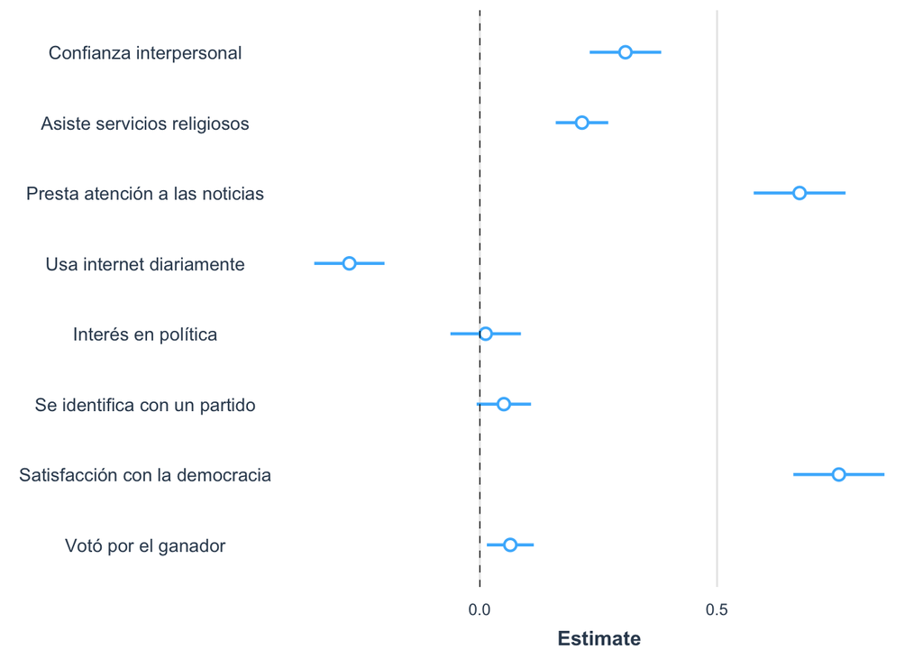

```r
plot_summs(modelo142_2, coefs=c("Confianza interpersonal" = "it1r",
                            "Asiste servicios religiosos" = "q5a01",
                            "Presta atención a las noticias" = "newsattn",
                            "Usa internet diariamente" = "useinternet",
                            "Interés en política" = "polinterest",
                            "Se identifica con un partido" = "idpty",
                            "Satisfacción con la democracia" = "satisdem",
                            "Votó por el ganador" = "votewinner"))
```

De esta manera se han replicado los gráficos presentados en este reporte 142 de la Serie Perspectivas usando los datos del Barómetro de las Américas por LAPOP.

[figure not shown]

[figure not shown]

[figure not shown]